# 九月第三周

2018年 九月 24日

## 一、清醒时间安排情况

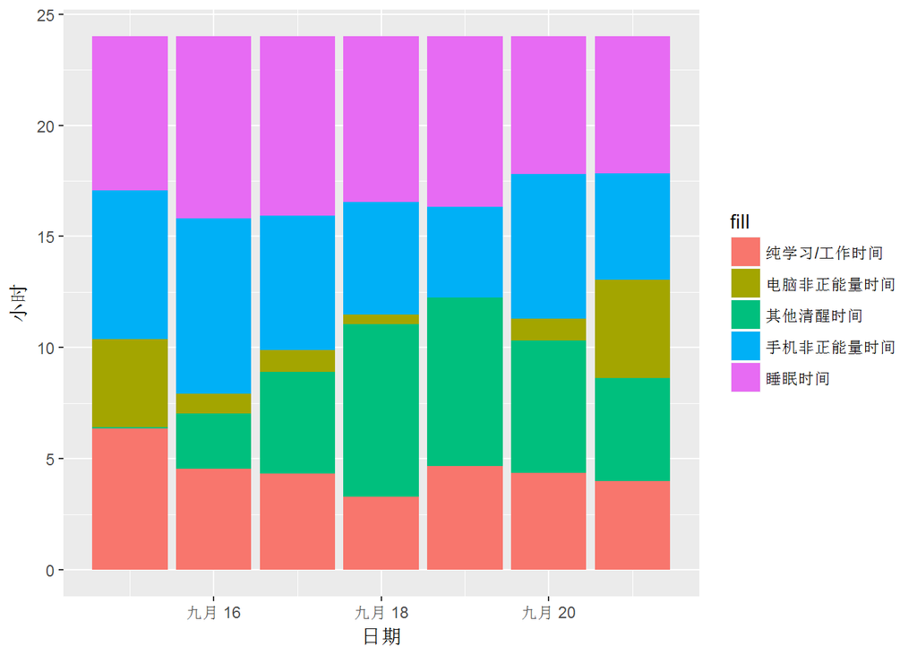

图中反映了本期7天每日时间的构成及其变化情况

启动时间，反映了本人自起床开始到做本日第一件事，平均要花1.99小时，占全部清醒时间的11.87%。

纯学习/工作时间，平均为4.51小时，占清醒时间比重为26.92%。

手机非正能量时间每天为5.87小时,占清醒时间比重为35.04%。

电脑非正能量时间平均每天为1.66小时,占清醒时间比重为9.93%。

## 二、睡眠状况

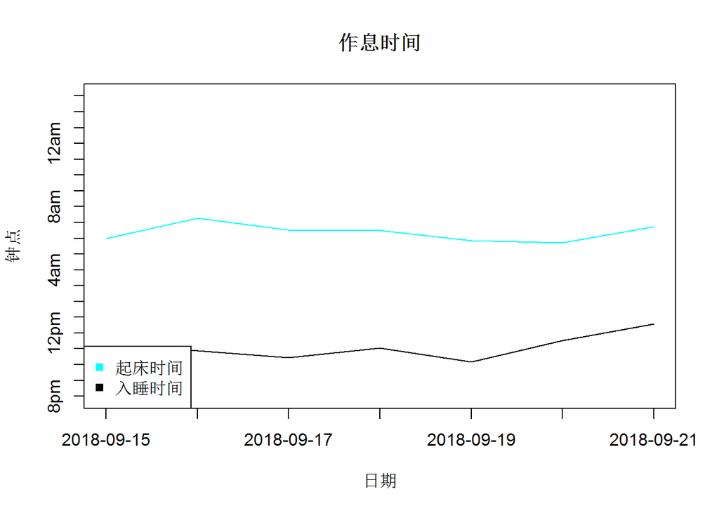

“作息时间”图反映了本期本人每日的入睡与起床时间，在这一期间，本人平均每天11点6分入睡，6点22分起床，睡眠时间平均为7.24小时。

入睡时间与起床时间没有显著的相关关系，相较而言，起床时间的波动要比入睡时间更小。

从线性趋势上看，总睡眠时间趋向减少，深睡眠时间趋向增加，睡眠质量向增加发展。

## 三、学习/工作状况

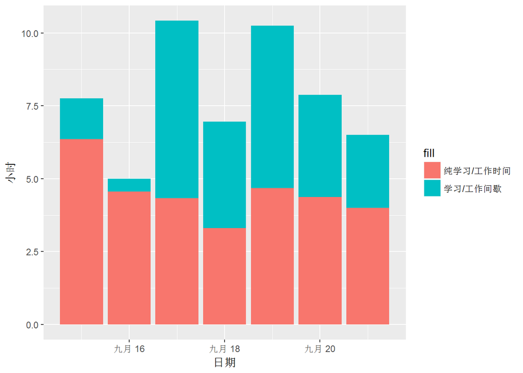

本期平均每日毛学习时间/工作时间为7.82小时，呈增加趋势。

纯学习时间/工作时间为4.51小时，呈减少趋势，用于学习/工作的时间达到了平均水平。

时间利用比为1.73，并未处于学习/工作状况。

### 核心时间

核心时间指的是完全由自主学习/工作构成，推动当前主要问题进度的时间；最近一周的核心时间为6.02小时，占纯学习/工作时间的19%。

就最近一个月而言，最近一周核心时间达到了平均水平。

就今年而言，最近一周用于核心学习/工作的时间达到了平均水平。

## 四、娱乐时间

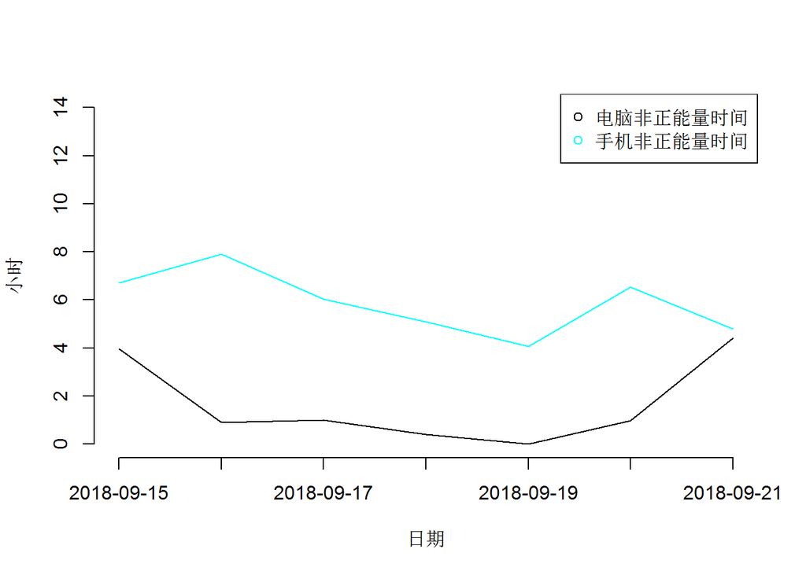

平均每日使用手机时间为6.3小时，呈减少趋势；其中非正能量时间5.87小时，呈减少趋势，与纯学习/工作时间没有显著的相关关系。

平均每日使用电脑时间为2.22小时；其中非正能量时间为1.66小时，呈增加趋势，与纯学习/工作时间没有显著的相关关系。

两者之和 与纯学习/工作时间 没有显著的相关关系。